# Máster Universitario en Ciencia de Datos

# Tipología y ciclo de vida de los datos aula 2: PR2

Autor: Cristhyan Naranjo

# 1 Detalles de la actividad

## 1.1 Descripción

En esta práctica se elabora un caso práctico orientado a aprender a identificar los datos relevantes para un proyecto analítico y usar las herramientas de integración, limpieza, validación y análisis de las mismas.

## 1.2 Objetivos

- Aprender a aplicar los conocimientos adquiridos y su capacidad de resolución de problemas en entornos nuevos o poco conocidos dentro de contextos más amplios o multidisciplinarios.
- Saber identificar los datos relevantes y los tratamientos necesarios (integración, limpieza y validación) para llevar a cabo un proyecto analítico.
- Aprender a analizar los datos adecuadamente para abordar la información contenida en los datos.
- Identificar la mejor representación de los resultados para aportar conclusiones sobre el problema planteado en el proceso analítico.
- Actuar con los principios éticos y legales relacionados con la manipulación de datos en función del ámbito de aplicación.
- Desarrollar las habilidades de aprendizaje que les permitan continuar estudiando de un modo que tendrá que ser en gran medida auto dirigido o autónomo.
- Desarrollar la capacidad de búsqueda, gestión y uso de información y recursos en el ámbito de la ciencia de datos.

## 1.3 Competencias

- Capacidad de analizar un problema en el nivel de abstracción adecuado a cada situación y aplicar las habilidades y conocimientos adquiridos para abordarlo y resolverlo.
- Capacidad para aplicar las técnicas específicas de tratamiento de datos (integración, transformación, limpieza y validación) para su posterior análisis. # Resolución

# 2 Descripción del dataset

Este dataset proviene de un web scrapping realizado el día 17 de abril del 2020 en la pagina “Trivago.com” a partir de un código propio y usando una lista de nombres de varios hoteles de Colombia (previamente ajustados para ser reconocidos por la pagina) y usando como parámetro la misma cantidad de días de estadía en las mismas fechas.

Las variables obtenidas fueron las siguientes:

```r
des<-read.csv2("D:/Dane/trabajo hoteles/14-03/des.csv")
knitr::kable(data.frame(Nombres=as.vector(des$Nombre),Descripcion=as.vector(des$Descripcion)))
```

| Nombres | Descripcion |
| --- | --- |
| X | Identificador |
| Nombre.buscado | Nombre que se uso en la busqueda |
| Nombre.trivago | Nombre que devolvio trivago |
| Codigo | Codigo interno del hotel |
| Precio.mb | Precio mas bajo encontrado |
| Hotel.mb | Hotel con el precio mas bajo |
| Link | Link con la direccion de la publicacion |
| Bloque.1 | Bloque con informacion general |
| Bloque.2 | Bloque con informacion general |
| Wifi.lobby | Si el hotel tiene wifi en el lobby |
| Wifi.habitacion | Si el hotel tiene wifi en la habitacion |
| Piscina | Si el hotel tiene wifi en la piscina |
| Spa | Si el hotel tiene spa |
| Parqueadero | Si el hotel tiene parqueadero |
| Mascota | Si el hotel tiene mascota |
| Aire.acondicionado | Si el hotel tiene aire acondicionado |
| Restaurante | Si el hotel tiene restaurante |
| Bar | Si el hotel tiene bar |
| Gimnasio | Si el hotel tiene gimnasio |
| Estrellas | Nivel de estrellas del hotel |
| Puntaje | Puntaje dado por los usuarios |
| Opinion.cualitativa | Opinion de los usuarios en un parrafo |
| Cantidad.opiniones | Cantidad de opiniones |
| Latitud | Latitud de la ubicación del hotel |
| Longitud | Longitud de la ubicación del hotel |

## 2.1 Importancia y objetivos de los análisis

Se pretende identificar que servicios opcionales afectan en mayor medida el precio por habitación ofrecida por un hotel, lo cual puede ser una buena guía para que los negocios hoteleros mejoren sus servicio y sean mas competitivos, o también como base para saber que hoteles tienen mejor relación costo-servicio.

# 3 Limpieza de los datos

Usaremos las siguientes librerías

```r
library(knitr)
library(naniar)
library(dplyr)
library(VIM)
```

```r
library(lattice)
library(plotrix)
library(vioplot)
library(factoextra)
library(leaflet)
```

Se utilizara el siguiente data set

```r
data<-read.csv2("D:/Dane/trabajo hoteles/14-03/muestras/Trivago_2020-04-17_.csv")
data1<-data
attach(data)
head(data,1)
```

```
##   X               Nombre.buscado               Nombre.trivago  Codigo Precio.mb
## 1 1 Hotel Santa Barbara boutique Hotel Santa Barbara Boutique 3758032  $257.294
##      Hotel.mb
## 1 Booking.com
##                                                                                                                                                                                                                                                                                                          …
## 1 https://www.trivago.com.co/?aDateRange%5Barr%5D=2020-10-09&aDateRange%5Bdep%5D=2020-10-13&aPriceRange%5Bfrom%5D=0&aPriceRange%5Bto%5D=0&iRoomType=7&aRooms%5B0%5D%5Badults%5D=2&cpt2=3758032%2F100&hasList=1&hasMap=0&bIsSeoPage=0&sortingId=1&slideoutsPageItemId=&iGeoDistanceLimit=20000&address=&ad…
##     Bloque.1
## 1 NA= , = ,
##                                                                                                                                                                                                                                                                                                          …
## 1 Habitación Doble - Desayuno incluido en el precio - Conexión WiFi gratuita\nDesayuno gratis\n$185.018\n/noche\nMostrar 11 ofertas más (incl. Cancelación gratuita, Desayuno gratis, Paga en el hotel)\nHabitación Estándar (cama doble) (cama matrimonial queen size)\nCancelación gratuita\nDesayuno g…
##   Wifi.lobby Wifi.habitacion Piscina   Spa Parqueadero Mascotas
## 1       True            True   False False        True    False
##   Aire.acondicionado Restaurante   Bar Gimnasio Estrellas Puntaje
## 1              False       False False    False         3     8.9
##   Opinion.cualitativa cantidad.opiniones  Latitud  Longitud
## 1           Excelente                262 4.702236 -74.04351
```

Empezaremos revisando cuantos registros, y cuantas columna tiene el dataset.

```r
nrow(data)
```

```
## [1] 1048
```

```r
ncol(data)
```

```
## [1] 25
```

```r
des<-read.csv2("D:/Dane/trabajo hoteles/14-03/des.csv")
clase <- sapply(data,class)
kable(data.frame(variables=names(clase),clase=as.vector(clase),Descripcion=des$Descripcion))
```

| variables | clase | Descripcion |
| --- | --- | --- |
| X | integer | Identificador |
| Nombre.buscado | character | Nombre que se uso en la busqueda |
| Nombre.trivago | character | Nombre que devolvio trivago |
| Codigo | character | Codigo interno del hotel |
| Precio.mb | character | Precio mas bajo encontrado |
| Hotel.mb | character | Hotel con el precio mas bajo |
| link | character | Link con la direccion de la publicacion |
| Bloque.1 | character | Bloque con informacion general |
| Bloque.2 | character | Bloque con informacion general |
| Wifi.lobby | character | Si el hotel tiene wifi en el lobby |
| Wifi.habitacion | character | Si el hotel tiene wifi en la habitacion |
| Piscina | character | Si el hotel tiene wifi en la piscina |
| Spa | character | Si el hotel tiene spa |
| Parqueadero | character | Si el hotel tiene parqueadero |
| Mascotas | character | Si el hotel tiene mascota |
| Aire.acondicionado | character | Si el hotel tiene aire acondicionado |
| Restaurante | character | Si el hotel tiene restaurante |
| Bar | character | Si el hotel tiene bar |
| Gimnasio | character | Si el hotel tiene gimnasio |
| Estrellas | character | Nivel de estrellas del hotel |
| Puntaje | character | Puntaje dado por los usuarios |
| Opinion.cualitativa | character | Opinion de los usuarios en un parrafo |
| cantidad.opiniones | character | Cantidad de opiniones |
| Latitud | character | Latitud de la ubicación del hotel |
| Longitud | character | Longitud de la ubicación del hotel |

## 3.1 Selección de los datos de interés

Se retiraran las variables: Código,link,Bloque1,Bloque2 porque no ofrecen información de interés para el análisis.

También la variable X porque es redundante y puede afectar al momento de buscar registros duplicados.

```r
data<-data%>%select(-c(X,Codigo,link,Bloque.1,Bloque.2))
```

## 3.2 Ceros y elementos vacíos

Revisamos las columnas buscando datos faltantes

```r
colSums(is.na(data))
```

```
##      Nombre.buscado      Nombre.trivago           Precio.mb            Hotel.mb
##                 524                   0                   0                   0
##          Wifi.lobby     Wifi.habitacion             Piscina                 Spa
##                   0                   0                   0                   0
##         Parqueadero            Mascotas  Aire.acondicionado         Restaurante
##                   0                   0                   0                   0
##                 Bar            Gimnasio           Estrellas             Puntaje
##                   0                   0                   0                   0
## Opinion.cualitativa  cantidad.opiniones             Latitud            Longitud
##                 524                 524                 525                 525
```

```r
colSums(data=="NULL")
```

```
##      Nombre.buscado      Nombre.trivago           Precio.mb            Hotel.mb
##                  NA                 547                 675                 675
##          Wifi.lobby     Wifi.habitacion             Piscina                 Spa
##                 727                 727                 728                 728
##         Parqueadero            Mascotas  Aire.acondicionado         Restaurante
##                 728                 728                 728                 728
##                 Bar            Gimnasio           Estrellas             Puntaje
##                 728                 728                 744                 547
## Opinion.cualitativa  cantidad.opiniones             Latitud            Longitud
##                  NA                  NA                  NA                  NA
```

Vemos que el dataset tiene muchos valores faltantes, pero como conocemos el proceso con el que se produjo el dataset, sabemos por ejmplo que si falta la variable “nombre buscado” implica que el programa no pudo conseguir la demás información, por lo que podemos eliminar con confianza los registros con valores faltantes en esta variable. Para los valores faltantes de la variable “Precio.mb” es posible realizar una imputación siempre y cuando se tengan suficientes variables adicionales, así que borramos los registros donde las variables “Precio.mb” y “Wifi.lobby” sean nulas (ya que si falta wifi.lobby implica que faltan las demás variables de ese grupo) que corresponden a los registros con datos insuficientes.

```r
data<-data[!is.na(data$Nombre.buscado),]
data<-data[data$Precio!="NULL" & data$Wifi.lobby!="NULL",]
colSums(is.na(data))
```

```
##      Nombre.buscado      Nombre.trivago           Precio.mb            Hotel.mb
##                   0                   0                   0                   0
##          Wifi.lobby     Wifi.habitacion             Piscina                 Spa
##                   0                   0                   0                   0
##         Parqueadero            Mascotas  Aire.acondicionado         Restaurante
##                   0                   0                   0                   0
##                 Bar            Gimnasio           Estrellas             Puntaje
##                   0                   0                   0                   0
## Opinion.cualitativa  cantidad.opiniones             Latitud            Longitud
##                   0                   0                   1                   1
```

```r
colSums(data=="NULL")
```

```
##      Nombre.buscado      Nombre.trivago           Precio.mb            Hotel.mb
##                   0                   0                   0                   0
##          Wifi.lobby     Wifi.habitacion             Piscina                 Spa
##                   0                   0                   1                   1
##         Parqueadero            Mascotas  Aire.acondicionado         Restaurante
##                   1                   1                   1                   1
##                 Bar            Gimnasio           Estrellas             Puntaje
##                   1                   1                  84                   0
## Opinion.cualitativa  cantidad.opiniones             Latitud            Longitud
##                   0                   0                  NA                  NA
```

Ahora tenemos que la mayor cantidad de valores faltantes está en la variable “Estrellas”, pero esta variable puede ser aproximada por que tenemos información que pueden servir para clasificar los hoteles, pero primero trataremos las demás variables.

Revisamos el registro que tiene valores faltantes para la variable “piscina”

```r
data[which(data$Piscina=="NULL"),]
```

```
##             Nombre.buscado         Nombre.trivago Precio.mb    Hotel.mb
## 729 MONASTERIO SAN AGUSTIN Monasterio San Agustín  $434.535 Booking.com
##     Wifi.lobby Wifi.habitacion Piscina  Spa Parqueadero Mascotas
## 729      False           False    NULL NULL        NULL     NULL
##     Aire.acondicionado Restaurante  Bar Gimnasio Estrellas Puntaje
## 729               NULL        NULL NULL     NULL      NULL     8.7
##     Opinion.cualitativa cantidad.opiniones Latitud Longitud
## 729           Excelente                 22    <NA>     <NA>
```

```r
data<-data[data$Piscina!="NULL",]
```

Al revisar la base encontramos algunas valores anómalos como por ejemplo

```r
data$Puntaje[177]
```

```
## [1] "/"
```

```r
data$Opinion.cualitativa[28]
```

```
## [1] "("
```

Para tratarlos primero eliminaremos estos valores y después los imputaremos

```r
# Estrellas
data$Estrellas[data$Estrellas=="NULL"]<-NA
suppressWarnings(data$Estrellas<-kNN(data)$Estrellas)
# Opinion cualitativa
data$Opinion.cualitativa[data$Opinion.cualitativa=="Puntuación no disponible"]<-NA
data$Opinion.cualitativa[data$Opinion.cualitativa=="("]<-NA
suppressWarnings(data$Opinion.cualitativa<-kNN(data)$Opinion.cualitativa)
# Puntaje
data$Puntaje<-as.numeric(data$Puntaje)
suppressWarnings(data$Puntaje<-kNN(data)$Puntaje)
```

Antes de imputar el precio modificaremos esta variable para que sea manejada como numérica

```r
data$Precio.mb<-gsub("[.]","",data$Precio.mb)
data$Precio.mb<-gsub("[^0-9]","",data$Precio.mb)
data$Precio.mb<-as.numeric(data$Precio.mb)
suppressWarnings(data$Precio.mb<-kNN(data)$Precio.mb)

colSums(is.na(data))
```

```
##      Nombre.buscado      Nombre.trivago           Precio.mb            Hotel.mb
##                   0                   0                   0                   0
##          Wifi.lobby     Wifi.habitacion             Piscina                 Spa
##                   0                   0                   0                   0
##         Parqueadero            Mascotas  Aire.acondicionado         Restaurante
##                   0                   0                   0                   0
##                 Bar            Gimnasio           Estrellas             Puntaje
##                   0                   0                   0                   0
## Opinion.cualitativa  cantidad.opiniones             Latitud            Longitud
##                   0                   0                   0                   0
```

```r
colSums(data=="NULL")
```

```
##      Nombre.buscado      Nombre.trivago           Precio.mb            Hotel.mb
##                   0                   0                   0                   0
##          Wifi.lobby     Wifi.habitacion             Piscina                 Spa
##                   0                   0                   0                   0
##         Parqueadero            Mascotas  Aire.acondicionado         Restaurante
##                   0                   0                   0                   0
##                 Bar            Gimnasio           Estrellas             Puntaje
##                   0                   0                   0                   0
## Opinion.cualitativa  cantidad.opiniones             Latitud            Longitud
##                   0                   0                   0                   0
```

```r
nrow(data)
```

```
## [1] 320
```

Por fin logramos un dataset adecuado con 320 registros, guardamos este dataset procesado.

```r
write.csv2(data,"Trivago_2020-04-17_pro.csv")
```

## 3.3 Valores extremos

Analizamos la variable precio

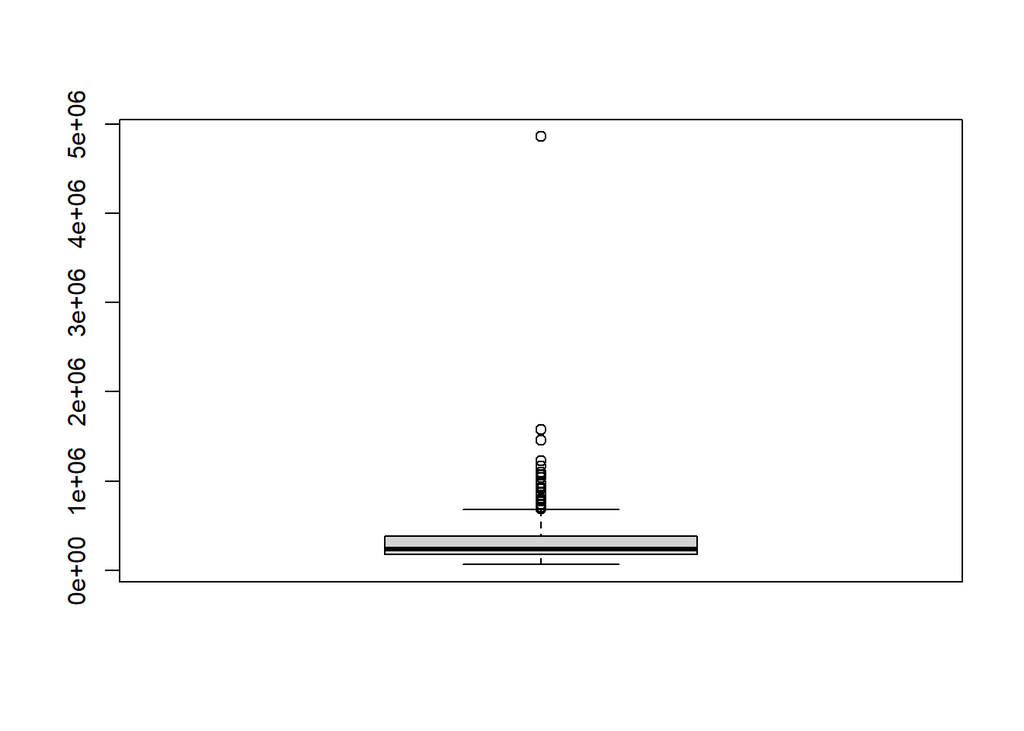

```
##  [1] 1575471  909034 1098756  877356  743778  733066 1575448 1460760 1224690
## [10] 1579499  778771 1071719  866343  739177  793023  703396 1066429 1171652
## [19] 1171652 1039176  791928  924520  840190  690323  732210  976977 4858722
## [28]  915303  728854  701682
```

```r
boxplot(data$Precio.mb)$out
```

Vemos que esta variable presenta demasiados valores extremos, esto puede ser causado a que en la muestra tenemos hoteles de todos os tipos, para corregir esto podemos crear subconjuntos homogéneos a partir de estratos usando para esto las estrellas.

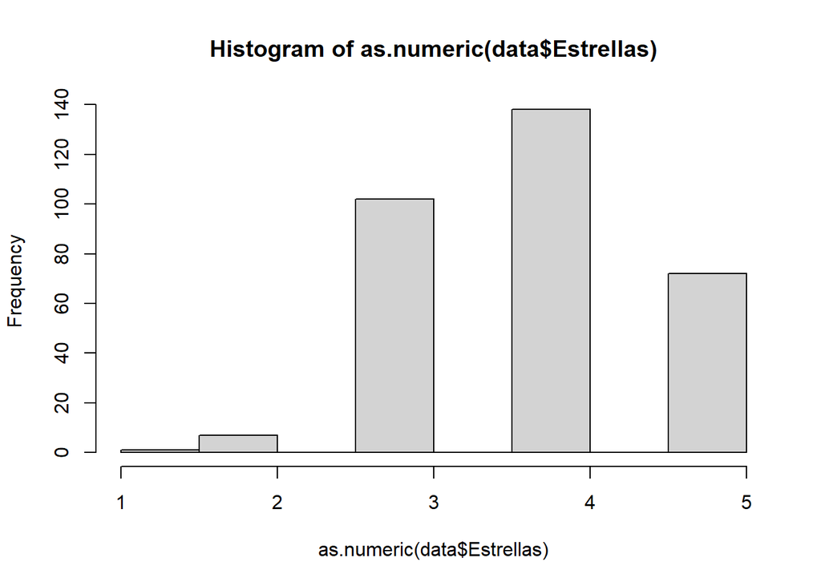

```r
hist(as.numeric(data$Estrellas))
```

A partir de la información del histograma, el resto del análisis solo usaremos hoteles de 4 estrellas porque son los mas populares

```r
data<-data[data$Estrellas==4,]
```

Volvemos a analizar esta variable

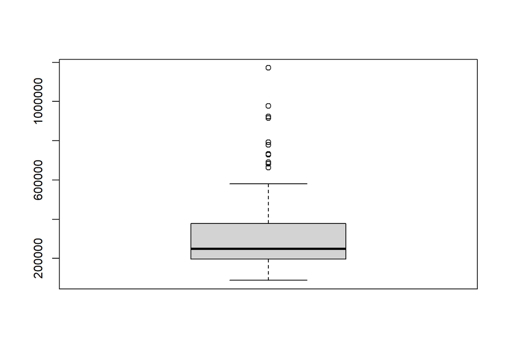

```r
hi<-boxplot(data$Precio.mb)$out
```

Aun tenemos valores extremos que vamos a conservar ya que sabemos que no provienen de errores y nos pueden dar indicios de los hoteles en los que mas cuesta una habitacion y la razón de este precio.

## 3.4 Cambio de formato

Cambiamos los niveles de las variables categóricas que corresponden a servicios adicionales para facilitar su análisis

```r
data$Wifi.lobby<-as.factor(data$Wifi.lobby)
data$Wifi.lobby<-as.numeric(data$Wifi.lobby)

data$Wifi.habitacion<-as.factor(data$Wifi.habitacion)
data$Wifi.habitacion<-as.numeric(data$Wifi.habitacion)

data$Piscina<-as.factor(data$Piscina)
data$Piscina<-as.numeric(data$Piscina)

data$Spa<-as.factor(data$Spa)
data$Spa<-as.numeric(data$Spa)

data$Spa<-as.factor(data$Spa)
data$Spa<-as.numeric(data$Spa)

data$Gimnasio<-as.factor(data$Gimnasio)
data$Gimnasio<-as.numeric(data$Gimnasio)

data$Parqueadero<-as.factor(data$Parqueadero)
data$Parqueadero<-as.numeric(data$Parqueadero)

data$Mascotas<-as.factor(data$Mascotas)
data$Mascotas<-as.numeric(data$Mascotas)

data$Aire.acondicionado<-as.factor(data$Aire.acondicionado)
data$Aire.acondicionado<-as.numeric(data$Aire.acondicionado)

data$Bar<-as.factor(data$Bar)
data$Bar<-as.numeric(data$Bar)

data$Restaurante<-as.factor(data$Restaurante)
data$Restaurante<-as.numeric(data$Restaurante)

data$Opinion.cualitativa<-as.factor(data$Opinion.cualitativa)
data$Opinion.cualitativa<-as.numeric(data$Opinion.cualitativa)

data$Estrellas<-as.numeric(data$Estrellas)

head(data,n=1)
```

```
##                   Nombre.buscado Nombre.trivago Precio.mb    Hotel.mb
## 13 HOTEL CAPITAL BOGOTA COLOMBIA    GHL Capital    228938 Booking.com
##    Wifi.lobby Wifi.habitacion Piscina Spa Parqueadero Mascotas
## 13          1               1       1   1           1        1
##    Aire.acondicionado Restaurante Bar Gimnasio Estrellas Puntaje
## 13                  1           2   2        2         4     8.9
##    Opinion.cualitativa cantidad.opiniones Latitud   Longitud
## 13                   2               2242 4.65831 -74.108192
```

# 4 Estudio estadístico

Empezamos realizando la matriz de correlación

```r
mu<-cbind(data$Precio.mb,data$Wifi.habitacion,data$Wifi.lobby,data$Piscina,data$Parqueadero,data$Spa,data$Mascotas,data$Aire.acondicionado,data$Restaurante,data$Bar,data$Gimnasio,data$Puntaje)
dd<-cor(mu)
dd
```

```
##               [,1]         [,2]        [,3]        [,4]        [,5]        [,6]
##  [1,]  1.000000000 -0.006262008  0.07662703  0.41290234 -0.26154115  0.31513397
##  [2,] -0.006262008  1.000000000  0.74357132  0.20695859  0.33352213  0.18844631
##  [3,]  0.076627035  0.743571322  1.00000000  0.22191676  0.23768204  0.14869043
##  [4,]  0.412902341  0.206958591  0.22191676  1.00000000 -0.07823012  0.28347335
##  [5,] -0.261541148  0.333522128  0.23768204 -0.07823012  1.00000000  0.13897056
##  [6,]  0.315133967  0.188446306  0.14869043  0.28347335  0.13897056  1.00000000
##  [7,]  0.200078928  0.309690066  0.27219622  0.19685675 -0.15471204  0.26614045
##  [8,]  0.155981514  0.383954372  0.41628689  0.42177569  0.21574021  0.16094908
##  [9,]  0.062607037  0.429290028  0.43833944  0.22191676  0.36835982  0.14869043
## [10,]  0.192083222  0.243401828  0.22962451  0.21768964  0.27831700  0.21598225
## [11,] -0.014581891  0.196928209  0.08522604  0.07258584  0.43087688  0.11934168
## [12,]  0.104958902  0.034109077 -0.15698178 -0.13800385  0.03788770 -0.07534302
##              [,7]       [,8]        [,9]       [,10]       [,11]       [,12]
##  [1,]  0.20007893  0.1559815  0.06260704  0.19208322 -0.01458189  0.10495890
##  [2,]  0.30969007  0.3839544  0.42929003  0.24340183  0.19692821  0.03410908
##  [3,]  0.27219622  0.4162869  0.43833944  0.22962451  0.08522604 -0.15698178
##  [4,]  0.19685675  0.4217757  0.22191676  0.21768964  0.07258584 -0.13800385
##  [5,] -0.15471204  0.2157402  0.36835982  0.27831700  0.43087688  0.03788770
##  [6,]  0.26614045  0.1609491  0.14869043  0.21598225  0.11934168 -0.07534302
##  [7,]  1.00000000  0.1523024 -0.02291214  0.02024954 -0.02791853  0.10157703
##  [8,]  0.15230244  1.0000000  0.32596049  0.27443963  0.13329275 -0.08859200
##  [9,] -0.02291214  0.3259605  1.00000000  0.44607384  0.20647545 -0.17668481
## [10,]  0.02024954  0.2744396  0.44607384  1.00000000  0.28893596 -0.04970320
## [11,] -0.02791853  0.1332927  0.20647545  0.28893596  1.00000000  0.22107880
## [12,]  0.10157703 -0.0885920 -0.17668481 -0.04970320  0.22107880  1.00000000
```

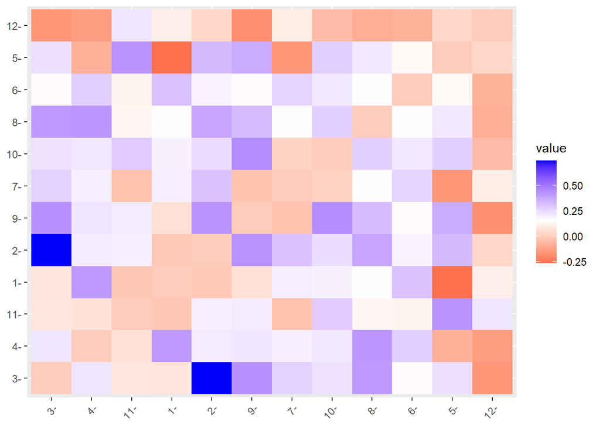

```r
ddd<-as.dist(dd)
fviz_dist(ddd)
```

Tanto en la matriz como en la gráfica vemos que en general el nivel de correlación entre las variables es muy bajo, la única significativa ocurre entre “wifi en el lobby” y “wifi en el cuarto”, lo que por el contesto tiene bastante lógica. Esto puede ser motivo de preocupación porque puede afectar los demás análisis

## 4.1 Contraste de hipótesis

Nos plantemos la siguiente pregunta:

¿La habitacion en un hotel con piscina es mas costosa?

Para esto dividiremos el dataset en dos conjuntos, uno con piscina y el otro sin este servicio

```r
dat1<-data[data$Piscina==1,]  # No tiene piscina
dat2<-data[data$Piscina==2,]  # Si tiene piscina
table(dat1$piscina)
```

```
## < table of extent 0 >
```

```r
table(dat1$piscina)
```

```
## < table of extent 0 >
```

$$H_0: \mu_1-\mu_2 =0$$

$$H_1: \mu_1-\mu_2 <0$$

Donde $\mu_1$ es la media de la población de la que se extrae la primera muestra y $\mu_2$ es la media de la población de la que extrae la segunda. Así, tomando $\alpha = 0, 05$ obtenemos.

```r
t.test(dat1$Precio.mb, dat2$Precio.mb,alternative = "less")
```

```
##
##  Welch Two Sample t-test
##
## data:  dat1$Precio.mb and dat2$Precio.mb
## t = -5.287, df = 93.192, p-value = 4.084e-07
## alternative hypothesis: true difference in means is less than 0
## 95 percent confidence interval:
##       -Inf -114639.6
## sample estimates:
## mean of x mean of y
##  240266.6  407438.1
```

Como se obtuvo un p_valor inferior al valor de significacion fijado, rechazamos la hipótesis nula, es decir un cuarto de hotel es mas costos si en el hotel hay piscina, cosa que va de acuerdo con lo esperado.

## 4.2 Regresión lineal

Si bien vimos que no existe una fuerte correlación en las variables, como practica haremos una regresión lineal para contrastar el precio entre un hotel que presta todos los servicios y uno sin ninguno. Creamos tres modelos, el primero solo con los servicios adicionales, al segundo se le agrego el puntaje y al tercero la opinión cualitativa

```r
modelo1 <- lm(Precio.mb ~ Wifi.habitacion+Wifi.lobby+Piscina+Parqueadero+Spa+Mascotas+Aire.acondicionado+Restaurante+Bar+Gimnasio, data = data)
modelo2<- lm(Precio.mb ~ Wifi.habitacion+Wifi.lobby+Piscina+Parqueadero+Spa+Mascotas+Aire.acondicionado+Restaurante+Bar+Gimnasio+Puntaje, data = data)
modelo3<- lm(Precio.mb ~ Wifi.habitacion+Wifi.lobby+Piscina+Parqueadero+Spa+Mascotas+Aire.acondicionado+Restaurante+Bar+Gimnasio+Puntaje+Opinion.cualitativa, data = data)
```

Realizamos la table con los coeficientes de determinación para elegir el modelo con mejor ajuste

```r
tabla.coeficientes <- matrix(c(1, summary(modelo1)$r.squared,
                               2, summary(modelo2)$r.squared,
                               3, summary(modelo3)$r.squared),
                             ncol = 2, byrow = TRUE)
tabla.coeficientes
```

```
##      [,1]      [,2]
## [1,]    1 0.3209345
## [2,]    2 0.3659791
## [3,]    3 0.3916561
```

Como se esperaba, ningún modelo tiene un ajuste suficientemente alto, aun así para probar tomaremos el modelo 3

```r
# Sin ningun servicio
pru1 <- data.frame(
  Wifi.habitacion=1
  ,Wifi.lobby=1
  ,Piscina=1
  ,Parqueadero=1
  ,Spa=1
  ,Mascotas=1
  ,Aire.acondicionado=1
  ,Restaurante=1
  ,Bar=1
  ,Gimnasio=1
  ,Puntaje=8.0
  ,Opinion.cualitativa=2
)

# Con todos los servicios

pru2 <- data.frame(
  Wifi.habitacion=2
  ,Wifi.lobby=2
  ,Piscina=2
  ,Parqueadero=2
  ,Spa=2
  ,Mascotas=2
  ,Aire.acondicionado=2
  ,Restaurante=2
  ,Bar=2
  ,Gimnasio=2
  ,Puntaje=8.0
  ,Opinion.cualitativa=2
)
```

```r
# Predecir el precio
predict(modelo3, pru1)
```

```
##      1
## 231147
```

```r
predict(modelo3, pru2)
```

```
##      1
## 414095
```

Según este modelo la diferencia de precios es de casi el doble, lo cual no esta alejado de la realidad.

## 4.3 Geocodificacion

Podemos aprovechar que disponemos de las coordenadas de los hoteles para poder visualizar sus ubicaciones. El primer mapa señala a cada hotel exactamente en su locación real, este nos permite por ejemplo ver que hay uno que se encuentra en mar abierto (al norte de la península de la guajira), lo que implica un error en los datos

```r
data$Longitud<-as.numeric(data$Longitud)
data$Latitud<-as.numeric(data$Latitud)


m<-leaflet(data = data[1:nrow(data),])  %>% addProviderTiles(providers$OpenStreetMap) %>%
  addMarkers(~Longitud, ~Latitud, popup = ~as.character(Hotel.mb))
m
```

[interactive chart not shown]

```r
m<-leaflet(data = data[1:nrow(data),])  %>% addProviderTiles(providers$OpenStreetMap) %>%
  addMarkers(~Longitud, ~Latitud, popup = ~as.character(Hotel.mb),clusterOptions = markerClusterOptions())
m
```

[interactive chart not shown]

Este es el mapa con los hoteles del dataset inicial

```r
data1$Longitud<-as.numeric(data1$Longitud)
data1$Latitud<-as.numeric(data1$Latitud)

m<-leaflet(data = data1[1:nrow(data1),])  %>% addProviderTiles(providers$OpenStreetMap) %>%
  addMarkers(~Longitud, ~Latitud, popup = ~as.character(Hotel.mb),clusterOptions = markerClusterOptions())
m
```

[interactive chart not shown]

# 5 Conclusión

Si revisamos los hoteles con los precios mas alto dentro de nuestro grupo de estudio (4 estrellas) tenemos

```r
data[62,]
```

```
##             Nombre.buscado               Nombre.trivago Precio.mb   Hotel.mb
## 248 HOTEL LOS DELFINES SAN Hotel Decameron Los Delfines   1171652 lol.travel
##     Wifi.lobby Wifi.habitacion Piscina Spa Parqueadero Mascotas
## 248          2               2       2   1           1        1
##     Aire.acondicionado Restaurante Bar Gimnasio Estrellas Puntaje
## 248                  2           2   2        1         4     7.7
##     Opinion.cualitativa cantidad.opiniones  Latitud Longitud
## 248                   1                227 12.58299 -81.6896
```

```r
data[61,]
```

```
##          Nombre.buscado     Nombre.trivago Precio.mb    Hotel.mb Wifi.lobby
## 246 DECAMERON AQUARIUM  Decameron Aquarium   1171652 Booking.com          2
##     Wifi.habitacion Piscina Spa Parqueadero Mascotas Aire.acondicionado
## 246               1       2   1           1        1                  2
##     Restaurante Bar Gimnasio Estrellas Puntaje Opinion.cualitativa
## 246           2   2        1         4     7.4                   2
##     cantidad.opiniones  Latitud Longitud
## 246                751 12.58051 -81.6882
```